# 9: Statistica Elementare con Numpy e Matplotlib

- Le funzioni statistiche fondamentali in Numpy
- Come disegnare l'istogramma delle frequenze
- Come e perché generare numeri casuali secondo una distribuzione data

## Nozioni fondamentali

La statistica ha un ruolo fondamentale in Fisica e in ogni campo scientifico a base sperimentale. Numpy fornisce tutti i metodi necessari per la manipolazione statistica dei dati. Affrontiamo questo argomento dopo aver introdotto Matplotlib perché la rappresentazione grafica dei dati è uno strumento indispensabile.

[figure not shown]

```python
import numpy as np
import matplotlib.pyplot as plt
```

Dati in un array numpy.

```python
dati = np.array([1.95, 1.96, 1.90, 1.91, 1.84, 1.81, 2.06, 1.99, 1.93, 1.97,
                 2.02, 1.92, 1.95, 1.88, 1.87, 2.03, 1.85, 2.08, 1.96, 1.81,
                 2.07, 1.91, 1.79, 1.99, 1.97, 1.95, 1.96, 1.93, 1.83, 2.09,
                 2.02, 2.09, 1.84, 1.86, 1.96, 2.03, 1.93, 1.90, 1.94, 1.87,
                 1.97, 1.91, 1.87, 1.81, 2.06, 2.02, 1.96, 1.81, 1.93, 2.03,
                 1.92, 1.96, 1.80, 1.95, 1.91, 2.02, 2.03, 1.90, 2.03, 2.02,
                 1.96, 1.90, 1.98, 1.87, 1.92, 1.89, 1.84, 2.06, 1.93, 2.06,
                 1.93, 1.93, 1.90, 1.91, 1.90, 1.93, 1.86, 1.83, 1.96, 1.81,
                 2.03, 1.98, 1.84, 1.86, 1.96, 1.81, 1.98, 1.84, 1.86, 1.96,
                 1.92, 1.96, 1.85, 2.04, 2.00, 1.92, 1.90, 2.15, 1.94, 1.92])
```

```python
num_elementi = dati.size
print(num_elementi)
```

Dati al quadrato

```python
dati_sq = dati*dati
```

Il valor medio o media di un insieme di dati $x = [x_1,\cdots,x_n]$ è $$ <x> = \frac{\sum_{i=1}^n x_i}{n} $$ Numpy fornisce il metodo `mean` per calcolarla:

```python
media = dati.mean()
print(media)
```

La varianza di un insieme di dati $x = [x_1,\cdots,x_n]$ è $$ \sigma^2 = \,\, <(x - <x>)^2> \,\, = \frac{\sum_{i=1}^n (x_i-<x>)^2}{n} = \,\,<x^2> -<x>^2$$ Numpy fornisce il metodo `var` per calcolarla:

```python
varianza = dati.var()
print(varianza)
```

La deviazione standard, $\sigma = \sqrt{\sigma^2}$, si calcola usando il metodo `std`:

```python
deviazione_std = dati.std()
print(deviazione_std)
```

Talvolta è utile estrarre i dati più vicini di un numero dato di deviazioni standard al valor medio, oppure quelli che distano più di un numero dato di deviazioni standard dal valor medio. Nell'esempio selezioniamo i dati all'interno di una deviazione standard:

```python
dati1 = np.array([n for n in dati if np.absolute(n - media) < deviazione_std])
```

```python
print(dati1.size)
```

#### Imparare Facendo

1. Dato l'array

   ```
   my_arr = np.array([3.04645601, 2.97244915, 3.11895648, 2.23631771, 2.83300643,
          2.05404508, 2.75985706, 2.26921367, 1.37480605, 2.02558085,
          2.03489553, 2.9879711 , 1.96904577, 2.26633488, 2.25061096,
          2.19332838, 2.01392679, 3.11555729, 1.86606049, 3.05021054,
          3.03353987, 2.31818007, 2.79232123, 3.33861491, 3.28415856,
          1.99223361, 2.84573136, 1.79728384, 3.02507785, 1.66469195,
          1.9154713 , 2.43314196, 1.86340421, 1.90131182, 2.09963155,
          2.12451288, 1.77265763, 1.81662815, 2.0122717 , 2.82934715,
          1.72616883, 2.86297194, 2.9404613 , 2.96369557, 1.8376963 ,
          1.81889892, 2.08233386, 1.86941276, 1.83248482, 3.12861456,
          1.54804543, 2.89724744, 2.97500892, 2.28660094, 3.51159172,
          1.64804177, 2.9250396 , 2.98698285, 2.17577323, 2.43331005,
          2.03573614, 2.96237528, 3.14320927, 2.13393559, 2.55083613,
          1.72551903, 1.56344938, 3.31847721, 3.19368425, 2.81418586,
          2.79420806, 2.88605616, 2.08231959, 1.68927766, 1.89277468,
          2.03634711, 3.01241034, 1.95824444, 1.84229893, 1.79093756,
          2.16777509, 1.91055935, 2.16076815, 1.99936357, 2.42660732,
          2.09021026, 3.25206981, 2.55240002, 2.83482414, 2.0150959 ,
          3.31566771, 3.58996448, 2.58405186, 2.74445492, 2.80650089,
          1.25237511, 2.04484102, 1.95878434, 1.99383903, 1.63776293,
          3.08590679, 3.42000501, 1.69301131, 1.45661319, 2.75442641,
          3.01573607, 2.64220989, 2.37487723, 1.83034393, 1.74794294,
          1.92414741, 2.91175392, 3.25243102, 2.91543309, 3.22180813,
          1.89410574, 1.83451938, 1.60409685, 3.24371334, 2.04293352,
          2.89538543, 2.05009924, 2.20696778, 2.05073664, 1.83387137,
          2.07646022, 3.34614149, 3.30588549, 3.25491247, 1.55441846,
          2.19207954, 2.11273179, 2.92539792, 3.19288315, 1.2374957 ,
          2.17409141, 1.76835303, 2.12725474, 2.91318578, 2.96264334,
          2.18750678, 1.96060764, 3.41421698, 2.78839075, 1.56933989,
          1.64822396, 1.8383093 , 1.49851104, 3.03809049, 2.84892792,
          1.6809436 , 3.12957714, 3.01568747, 1.87809285, 1.71435392,
          1.83658257, 1.94510093, 3.04703205, 2.97698006, 1.99492519,
          3.07521061, 1.96260647, 2.91868837, 1.94448569, 2.96816534,
          2.90343856, 2.33124355, 1.88310601, 1.93171459, 2.54151343])
   ```

   calcolate la sua media e deviazione standard usando la loro definizione e la funzione **np.sum**.
2. Calcolate media e deviazione standard di `my_arr` usando i metodi **mean** e **var**.

## Istogramma delle frequenze

L'istogramma delle frequenze è sovente il modo migliore per un primo esame dei dati, mostrando con quale frequenza i valori in un dato intervallo o bin appaiono nei dati.

```python
min = dati.min()
print(min)
```

```python
max = dati.max()
print(max)
```

La conoscenza del minimo e del massimo valore dei dati è utile per determinare il `range` dei bin, cioè la coordinata dell'estremo inferiore del primo bin e la coordinata dell'estremo supereriore dell'ultimo bin. Il numero di bin deve essere adattato di volta in volta al set di dati per aiutare l'analisi.

```python
nbins = 10
xrange = (1.75, 2.20)
```

Nell'esempio seguente vengono inserite tre linee verticali per segnalare il valor medio e i valori della variabile a più e meno una deviazione standard dal valor medio (Non è necessario farlo sempre).

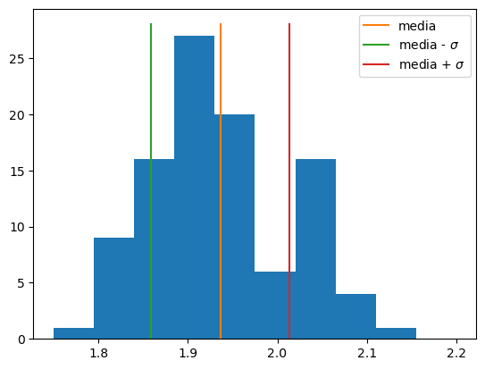

```python
fig, ax = plt.subplots()
nevent, bins, patches = ax.hist(dati, nbins, range=xrange)
ax.plot(np.ones(2)*media, [0,nevent.max()+1], label="media")
ax.plot(np.ones(2)*media-deviazione_std, [0,nevent.max()+1], label=r"media - $\sigma$")
ax.plot(np.ones(2)*media+deviazione_std, [0,nevent.max()+1], label=r"media + $\sigma$")
ax.legend();
```

```python
print(nevent)      # Numero di eventi in ciascun bin
```

```python
print(bins)        # Estremi dei bin
```

I patches sono le coordinate dei rettangoli (blu in questo caso) che vengono usati per disegnare l'istogramma.

Il metodo `hist` ha un parametro booleano `density` con default `False`. Se `density=True` ogni bin mostra il numero di eventi nel bin diviso per il numero totale di eventi e diviso per la larghezza del bin in modo che l'area sotto l'istogramma sia 1. Utile per confontare la densità dei dati con una densità di probabilità analitica, per esempio gaussiana.

```python
fig, ax = plt.subplots()
nevent, bins, patches = ax.hist(dati, nbins, range=xrange, density=True)
```

#### Imparare Facendo

Fate il diagramma delle frequenze dell'array **my_arr**. In particolare

1. Determinate un **range** ragionevole.
2. Variate il numero di bin, notando come sia un numero troppo piccolo che uno troppo grande mascherano l'andamento dei dati.
3. Valutate se il valor medio e la standard deviation sono parametri utili nella comprensione di questo set di dati

#### Attenzione!

Lo studio grafico dei dati non va mai trascurato.  
In un notebook separato anscombe.ipynb potete trovare un classico esempio di quanto sia pericoloso affidarsi ai soli parametri statisti fondamentali. Vengono mostrati quattro set di dati che hanno la stessa media, la stessa deviazione standard e vengono interpolati dalla stessa retta pur essendo completamente diversi.

[figure not shown]

## Numeri Casuali

La generazione di numeri casuali secondo una distribuzione data ha numerose importanti applicazioni. Il notebook 11_MetodoMontecarlo fornisce una discussione più approfondita e diversi esempi.  
Nelle versioni più recenti di Numpy (>1.17) è stata introdotto un oggetto `default_rng` i cui metodi possono essere utilizzati per generare set di valori distribuiti secondo le singole distribuzioni di probabilità.

```python
import matplotlib.pyplot as plt
from numpy.random import default_rng

rng = default_rng()

#help(np.random.default_rng)
#help(rng)
```

### Alcuni esempi con distribuzioni di uso frequente:

- Come generare numeri distribuiti secondo la distribuzione normale standard, con valor medio $\mu = 0.0$, e deviazione standard $\sigma = 1.0\,$.

```python
m1 = rng.normal(size=2000)
```

```python
print(m1[170:202])
```

```python
nbins = 30
xrange = (-5, 5)    # ntupla
fig, ax = plt.subplots()
nevent, bins, patches = ax.hist(m1, nbins, range=xrange)
```

- Come generare numeri distribuiti secondo la distribuzione normale con $\mu = -2.0,\, \sigma = 0.3\,$.

```python
m2 = rng.normal(loc=-2., scale=0.3, size=2000)
```

```python
nbins = 300
xrange = (-5, 1)    # ntupla
fig, ax = plt.subplots()
nevent, bins, patches = ax.hist(m2, nbins, range=xrange)
```

- Un modo di generare numeri **reali** secondo la distribuzione uniforme (tutti i punti sono equiprobabili) standard (L'intervallo di definizione è $[0,1]$).

```python
#help(rng.uniform)
```

```python
m3 = rng.uniform(size=2000)
```

```python
print('m3[0:10]: ',m3[0:10])
```

```python
nbins = 12
xrange = (-0.1, 1.1)    # ntupla
fig, ax = plt.subplots()
nevent, bins, patches = ax.hist(m3, nbins, range=xrange)
```

- Un modo di generare numeri **interi** uniformemente distribuiti fra un minimo (incluso) e un massimo (escluso).

```python
#help(rng.integers)
```

```python
m4 = rng.integers(0, high=100, size=1500)
print(m4[30:72])
```

```
In letteratura si trovano ancora i generatori di numeri casuali meno recenti (sempre in numpy.random)
======================================================================================================
rand                 Uniformly distributed values.
randn                Normally distributed values.
ranf                 Uniformly distributed floating point numbers.
randint              Uniformly distributed integers in a given range.
======================================================================================================
```

Si può fissare il "seme" del generatore di numeri casuali in modo da ottenere la stessa sequenza più volte. Utile qundo si vogliono capire le analisi statistiche fatte da qualcun altro.

```python
rng1 = default_rng(12345)
rng2 = default_rng(12345)
```

```python
m3_1 = rng1.uniform(size=200)
```

```python
m3_2 = rng2.uniform(size=200)
```

```python
print(m3_1 == m3_2)
```

```python
rng3 = default_rng(12345)
rng4 = default_rng(12345)
```

```python
m1_1 =rng3.normal(size=1000)
#m1_1
```

```python
m1_2 =rng4.normal(size=1000)
#m1_2
```

```python
print(all(m1_1 == m1_2))
```

[figure not shown]

#### Imparare Facendo

Producete campioni casuali estratti da una distribuzione normale, con valor medio $\mu = 3.$ e deviazione standard $\sigma = 0.7$, di 50, 100, 500, 5000 elementi. Di ciascun campione

1. Fate l'istogramma delle frequenze.
2. Sovrapponete all'istogramma delle frequenze la funzione densità di probabilità gaussiana di valor medio $\mu$ e deviazione standard $\sigma$, facendo attenzione che la curva e l'istogramma siano confrontabili. Cosa è necessario fare?

## Distribuzioni di probabilità

Il modulo `scipy.stats` contiene le principali distribuzioni di probabilità, sia discrete che continue, funzioni che permettono di calcolare i parametri statistici più comuni di un set di dati, funzioni che eseguono test statistici e test di correlazione fra uno o più set di dati.  
Per ulteriori informazioni https://docs.scipy.org/doc/scipy/reference/stats.html.

### Distribuzione normale: $\,\,N(x) = \frac{\exp (-x^2/2)}{\sqrt{2\,\pi}}$

```python
import numpy as np
import scipy.stats as stats
import matplotlib.pyplot as plt
```

#### Grafico della distribuzione

```python
x = np.linspace(-3, 3, 100)
y_norm = stats.norm.pdf(x)

fig, ax = plt.subplots()
ax.plot(x, y_norm);
```

#### Parametri del set di dati

La funzione scipy.stats.describe calcola e restituisce i parametri statistici base di un array di dati: numero di dati, minimo e massimo valore, media, varianza, asimmetria e curtosi. `help(scipy.stats.describe)` per maggiori dettagli.

```python
print(stats.describe(y_norm))
```

#### Grafico della distribuzione cumulativa (cdf)

La distribuzione cumulativa $C(x)$ di una distribuzione di probabilità $N(x)$ è definita come $\,\,C(x) = \int_{-\infty}^x N(y)\, dy$

```python
y_norm_cumulative = stats.norm.cdf(x)
```

```python
fig, ax = plt.subplots()
ax.plot(x, y_norm_cumulative);
```

### Distribuzione di Poisson: $f(k) = \exp(-\mu)\, \frac{\mu^k}{k!}$

#### Grafico della distribuzione

La pmf è la probability mass function.

```python
mu = 1.5
k = np.arange(0, 10, 1)
n = stats.poisson.pmf(k, mu)
```

```python
fig, ax = plt.subplots()
ax.scatter(k, n);
```

#### Parametri del set di dati

```python
stats.describe(n)
```

Informazioni addizionali e buoni esempi: https://realpython.com/numpy-random-number-generator/

# Sommario 9: Statistica per la Fisica Sperimentale

## 🎯 Il Messaggio Centrale

**La statistica non è matematica astratta, è lo strumento per estrarre informazione dal rumore nelle misure sperimentali**

Tre pilastri fondamentali:

1. **Caratterizzare** i dati (media, deviazione standard)
2. **Visualizzare** le distribuzioni (istogrammi)
3. **Modellare** con distribuzioni teoriche (Gauss, Poisson)

## 📊 Parametri Statistici: Cosa Misurano Davvero

### I Magnifici Tre

```
media = dati.mean()     # Valore centrale
std = dati.std()        # Dispersione
var = dati.var()        # std²
```

### Quando Usarli e Quando NO

| Parametro | Utile quando | Ingannevole quando |
| --- | --- | --- |
| Media | Distribuzione simmetrica | Outliers presenti |
| Std | Distribuzione unimodale | Distribuzioni bimodali |
| Min/Max | Sempre | Mai sufficienti da soli |

**Regola d'oro**: I parametri numerici senza visualizzazione sono pericolosi (vedi Anscombe)

## 📈 Istogrammi: La Finestra sui Dati

### Il Pattern Standard

```
fig, ax = plt.subplots()
n, bins, patches = ax.hist(dati, bins=nbins, range=(xmin, xmax))
```

### Scelta Critica dei Bin

- **Troppo pochi** (< 10): Perdi struttura
- **Troppi** (> √n): Rumore domina
- **Regola empirica**: bins ≈ √(numero_dati)

### Normalizzazione per Confronto

```
# Per confrontare con teoria
ax.hist(dati, density=True)  # Area = 1
```

## 🎲 Generazione Numeri Casuali

### Il Nuovo Standard (NumPy > 1.17)

```
from numpy.random import default_rng
rng = default_rng(seed)  # seed per riproducibilità

# Distribuzioni principali
rng.normal(loc=μ, scale=σ, size=n)    # Gaussiana
rng.uniform(low, high, size=n)        # Uniforme
rng.poisson(lam=λ, size=n)            # Poisson
rng.integers(low, high, size=n)       # Interi uniformi
```

### Perchè Generare Dati Casuali?

1. **Test algoritmi**: Prima di dati reali
2. **Monte Carlo**: Simulazioni complesse
3. **Bootstrap**: Stima incertezze
4. **Validazione**: Confronto teoria-esperimento

## 📉 Distribuzioni Fondamentali per la Fisica

### Gaussiana (Normale)

**Quando**: Errori di misura, teorema limite centrale

```
# Media μ, deviazione σ
P(x) = exp(-(x-μ)²/2σ²) / √(2πσ²)
```

**Proprietà chiave**: 68% dati in ±σ, 95% in ±2σ

### Poisson

**Quando**: Eventi rari, decadimenti radioattivi

```
# Parametro λ (rate)
P(k) = λᵏ exp(-λ) / k!
```

**Proprietà chiave**: Media = Varianza = λ

### Uniforme

**Quando**: Errori di digitalizzazione, fase casuale

```
P(x) = 1/(b-a) per a ≤ x ≤ b
```

## ⚠️ I Pericoli della Statistica Ingenua

### 1. Il Paradosso di Anscombe

Quattro dataset con:

- Stessa media ✓
- Stessa deviazione standard ✓
- Stessa retta di fit ✓
- **Completamente diversi visivamente!**

### 2. Outliers Nascosti

```
# Un outlier può spostare la media
dati = [1, 2, 3, 4, 100]  # media = 22!
# Usa la mediana per robustezza
```

### 3. Distribuzioni Bimodali

Due picchi nascosti da media e std singole

## 🔬 Pattern per Analisi Dati Sperimentali

### Workflow Standard

```
# 1. Carica dati
dati = np.loadtxt('misure.txt')

# 2. Esplora visivamente
fig, (ax1, ax2) = plt.subplots(1, 2)
ax1.hist(dati, bins=30)
ax2.boxplot(dati)

# 3. Calcola parametri
μ, σ = dati.mean(), dati.std()

# 4. Identifica outliers
outliers = dati[np.abs(dati - μ) > 3*σ]

# 5. Confronta con teoria
x = np.linspace(dati.min(), dati.max(), 100)
teoria = stats.norm.pdf(x, μ, σ)
ax1.plot(x, teoria * n * bin_width)
```

### Test di Normalità

```
# Shapiro-Wilk test
statistic, p_value = stats.shapiro(dati)
if p_value < 0.05:
    print("Non gaussiano!")
```

## 💡 Best Practices

1. **Sempre visualizzare prima**: Grafico → Parametri → Conclusioni
2. **Controllare outliers**: 3σ rule o metodo IQR
3. **Seed per riproducibilità**: `rng = default_rng(12345)`
4. **Bin appropriati**: Non troppi, non troppo pochi
5. **Confrontare con teoria**: Sovrapporre curve teoriche

## 📊 Checklist Analisi Statistica

- Ho fatto l'istogramma dei dati?
- Ho controllato presenza di outliers?
- La distribuzione è unimodale?
- Media e mediana sono simili?
- Ho scelto bins appropriati?
- Ho confrontato con distribuzione teorica?
- Ho verificato le assunzioni statistiche?

## 🎓 Il Concetto Chiave

**"Tutti i modelli sono sbagliati, ma alcuni sono utili"** - George Box

La statistica non dà verità assolute ma strumenti per quantificare l'incertezza. In fisica sperimentale, l'onestà nell'analisi statistica è fondamentale: mostrare sempre i dati grezzi, dichiarare le assunzioni, quantificare le incertezze.